# Midterms Sentiment Analysis

Jose Bustos

2022-12-07

```r
# Load
#install.packages('tidytext')
#install.packages('textdata')
#install.packages('ggrepel')
library(tidyverse)
library(tidytext)
library(textdata)
library(stringr)
library(tm)
library(SnowballC)
library(RColorBrewer)
library(wordcloud)
library(syuzhet)
library(ggplot2)
library(dplyr)
library(ggrepel)
library(reshape2)
library(viridis)
library(paletteer)
```

### **Introduction**

Given the recent uptick in political rhetoric, every election cycle has become more important than the previous. No one in the U.S. can escape an election cycle as campaign advertising is seemingly everywhere on television and social media platforms such as Twitter. In the past, many citizens only voted during presidential elections. Voting trends have started to shift in recent years showing that more people are becoming actively involved in midterm elections. Social media has drastically changed the way people consume news, much of which is political. Given the rise in political activity seen through social media the hash tag midterms has started to trend on Twitter. A sentiment analysis of tweets based on the word midterms could well inform how the people in the US are feeling towards upcoming midterm elections.

```r
#load dataset
midterms <- read.csv('https://raw.githubusercontent.com/bustosjose/sentiment_analysis/main/clean_mid_terms22.csv',stringsAsFactors = F,header=T)

all_tweets <- paste(unlist(midterms$text), collapse =" ")
#create a corpus file

text.midterms2 <- Corpus(VectorSource(all_tweets))

#transform text

# Convert the text to lower case
text.midterms2 <- tm_map(text.midterms2, content_transformer(tolower))
# Remove numbers
text.midterms2 <- tm_map(text.midterms2, removeNumbers)
# Remove english common stopwords
text.midterms2 <- tm_map(text.midterms2, removeWords, stopwords("english"))
# Remove punctuations
text.midterms2 <- tm_map(text.midterms2, removePunctuation)
# Eliminate extra white spaces
text.midterms2 <- tm_map(text.midterms2, stripWhitespace)
# specify your custom stopwords as a character vector
text.midterms2  <- tm_map(text.midterms2, removeWords, c("https", "vote", "elections", "twitter",
                                                       "election", "amp", "can", "fuck", "just", "like",
                                                       "now", "they", "them", "shit", "get", "let",
                                                       "don", "trump", "will"))


# Build a term-document matrix
text.midterms2.dtm <- TermDocumentMatrix(text.midterms2)
text.dtm.m <- as.matrix(text.midterms2.dtm)


# Sort by decreasing value of frequency
dtm.frequency <- sort(rowSums(text.dtm.m),decreasing=TRUE)
dtm_data <- data.frame(word = names(dtm.frequency ),freq=dtm.frequency)
text_td <- tidy(text.midterms2.dtm)
```

#### Midterms Data Word Cloud

A Word Cloud was used to analyze the frequency of each word from all tweets collected. The midterms tweet data was collected through the use of the Twitter API utilizing the word midterms. Noticeably midterms is the top word used within the midterms data set. Other highly used words are GOP, democrats, Biden and politics.

[figure not shown]

```r
#text_td word cloud
tweet_cloud <- text_td[order(text_td$count, decreasing = TRUE, na.last=TRUE) , ]


set.seed(123)
wordcloud(words = tweet_cloud$term, freq =tweet_cloud$count, min.freq = 100,
          max.words=1000, random.order=FALSE, rot.per=0.30,
          colors=brewer.pal(8, "Dark2"))
```

#### Midterms Data Top 10 Words

A bar plot is employed to view the most frequent words in all of the tweet data collected. Based on graph midterms is the top word used. Following is democrats, GOP and Biden.

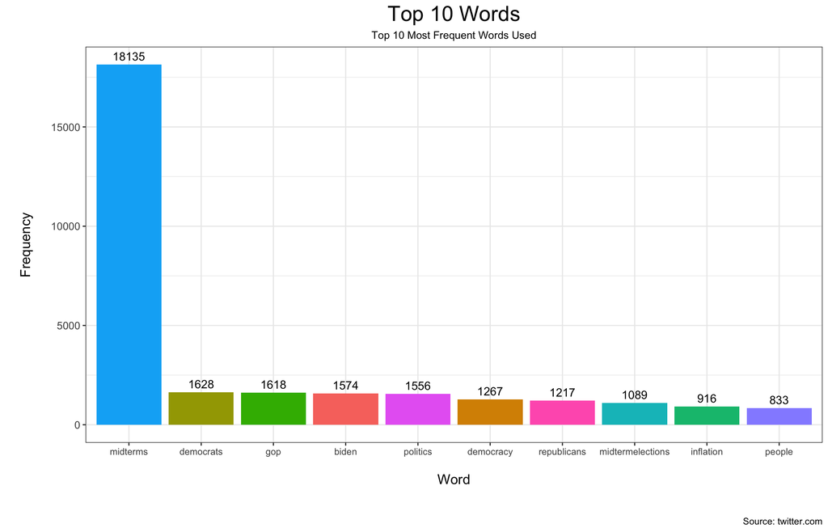

```r
# Plot the most frequent words
tweet_cloud[1:10,] %>%
  ggplot(aes( reorder(term, -count), count, fill = term)) +
  geom_col(show.legend = FALSE) +
  theme_bw() +
  geom_text(aes(label=paste0(count,"\n")))+
  labs(title = "Top 10 Words",
          subtitle = "Top 10 Most Frequent Words Used",
          x="\nWord\n",
          y="\nFrequency\n",
          caption="\nSource: twitter.com")+
     theme(
       plot.title=element_text(hjust=.5,size = 20),
       plot.subtitle=element_text(hjust=.5,size = 10),
       axis.text.y=element_text(size=10),
       axis.title.x=element_text(size=13),
       axis.title.y=element_text(size=13))
```

## Bing Lexicon

#### Bing Lexicon Word Cloud

The Bing sentiment lexicon categorizes words in a binary fashion, either positive or negative. Bellow is a Word Cloud that was created to show all of the words that appear in the tweets data set that matches with a word from the Bing lexicon. Win, right, good, recession are some of the most frequent words that appear most frequently.

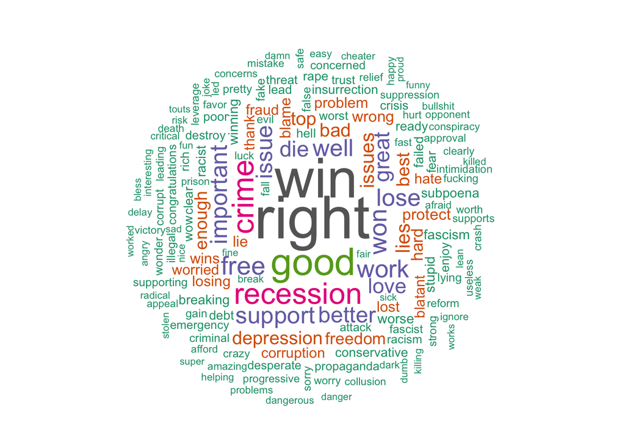

```r
#generate word cloud
mid_sentiment <- text_td %>% inner_join(get_sentiments('bing'), by = c(term= "word"))

sentiment_count <- mid_sentiment %>% group_by(sentiment) %>%
  summarize(freq = n())

set.seed(123)
wordcloud(words = mid_sentiment$term, freq = mid_sentiment$count, min.freq = 30,
          max.words=700,random.order=FALSE, rot.per=0.30,
          colors=brewer.pal(8, "Dark2"))
```

#### Bing Lexicon Comparison

Given the binary categorization of words in the Bing sentiment lexicon, we can compare the number of positive and negative sentiment frequency found in the data. The negative sentiment is more frequent in the tweet data. Let us analyze this finding further.

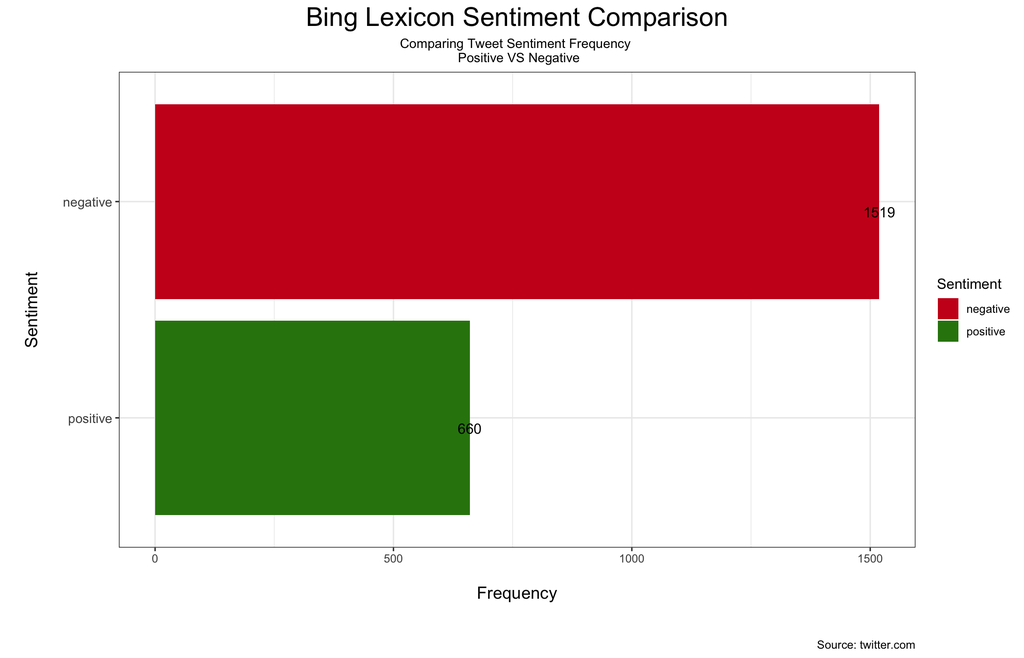

```r
#graph of positive tweets and negative tweets

ggplot(sentiment_count,aes(x=reorder(sentiment,freq),y=freq,fill=sentiment))+
  geom_bar(stat="identity")+
  coord_flip()+
  theme_bw()+
  geom_text(aes(label=paste0('\n',freq))) +
    labs(title = "Bing Lexicon Sentiment Comparison",
          subtitle = "Comparing Tweet Sentiment Frequency \n Positive VS Negative",
          x="\nSentiment\n",
          y="\nFrequency\n",
          caption="\nSource: twitter.com",
         fill = "Sentiment")+
     theme(
       plot.title=element_text(hjust=.5,size = 20),
       plot.subtitle=element_text(hjust=.5,size = 10),
       axis.text.y=element_text(size=10),
       axis.title.x=element_text(size=13),
       axis.title.y=element_text(size=13)) +
  scale_fill_manual(values = c("negative"= "#CB181D", "positive"="#2E830E"))
```

#### Bing Lexicon Top 10 Words

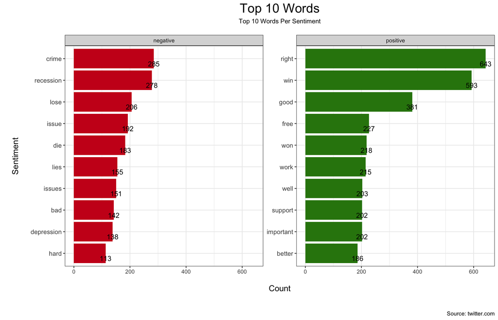

```r
### face wrap with 10 ten words per sentiment
bing_sent <- mid_sentiment

bing_sent <- bing_sent[order(bing_sent$count, decreasing = TRUE, na.last=TRUE) , ]
bing_sent2 <- bing_sent %>% filter(sentiment == 'positive') %>% slice(1:10)
bing_sent3 <-  bing_sent %>% filter(sentiment == 'negative') %>% slice(1:10)
bing_sent <- rbind(bing_sent2, bing_sent3)

bing_sent %>%
  ggplot(aes( reorder(term, count), count, fill = sentiment)) +
  geom_col(show.legend = FALSE) +
  theme_bw() +
  facet_wrap(~sentiment, scales = 'free_y') +
  geom_text(aes(label=paste0('\n',count))) +
  coord_flip() +
    labs(title = "Top 10 Words",
          subtitle = "Top 10 Words Per Sentiment\n",
          x="\nSentiment\n",
          y="\nCount\n",
          caption="\nSource: twitter.com")+
     theme(
       plot.title=element_text(hjust=.5,size = 20),
       plot.subtitle=element_text(hjust=.5,size = 10),
       axis.text.y=element_text(size=10),
       axis.title.x=element_text(size=13),
       axis.title.y=element_text(size=13)) +
  scale_fill_manual(values = c("negative"= "#CB181D", "positive"="#2E830E"))
```

## NRC Lexicon

#### NRC Lexicon Word Cloud

The NRC lexicon categorizes words with eight basic emotions (anger, fear, anticipation, trust, surprise, sadness, joy, and disgust) and two sentiments (negative and positive). Bellow is a Word Cloud that was created to show all of the words that appear in the tweets data set that matches with a word from the NRC lexicon. Democracy, politics, equality and inflation seem to be the most frequent words found both in the tweet data set and NRC lexicon.

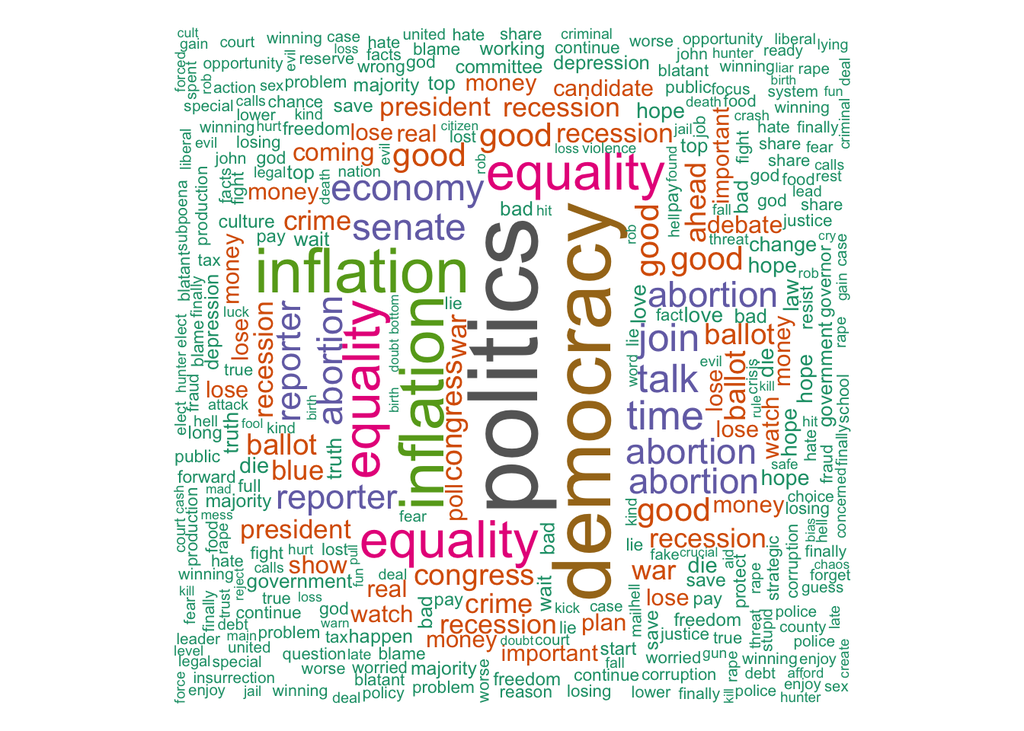

```r
#SENTIMENT 3

# graph of each type of feeling
mid_sentiment3 <- text_td %>% inner_join(get_sentiments('nrc'), by = c(term= "word"))

sentiment_count3 <- mid_sentiment3 %>% select(term, count, sentiment) %>% group_by(sentiment) %>%
  summarize(freq = n())


#generate word cloud
set.seed(123)
wordcloud(words = mid_sentiment3$term, freq = mid_sentiment3$count, min.freq = 3,
          max.words=1000, random.order=FALSE, rot.per=0.30,
          colors=brewer.pal(8, "Dark2"))
```

#### NRC Lexicon Comparison

Given the categorization of words in the NRC lexicon, we can compare the frequency of each word emotion and sentiment found. The negative sentiment is more frequent in the tweet data, and the positive sentiment comes second. The words are also categorized more than once, let us analyze this finding further.

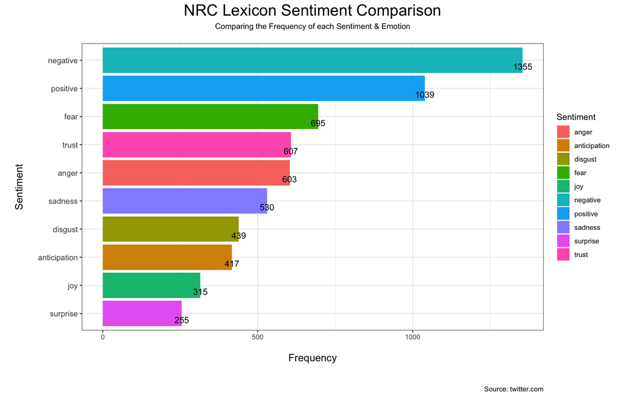

```r
ggplot(sentiment_count3,aes(x=reorder(sentiment,freq),y=freq,fill=sentiment))+
  geom_bar(stat="identity")+
  coord_flip()+
  theme_bw() +
  geom_text(aes(label=paste0('\n',freq))) +
    labs(title = "NRC Lexicon Sentiment Comparison",
          subtitle = "Comparing the Frequency of each Sentiment & Emotion\n",
          x="\nSentiment\n",
          y="\nFrequency\n",
          caption="\nSource: twitter.com",
         fill = "Sentiment")+
     theme(
       plot.title=element_text(hjust=.5,size = 20),
       plot.subtitle=element_text(hjust=.5,size = 10),
       axis.text.y=element_text(size=10),
       axis.title.x=element_text(size=13),
       axis.title.y=element_text(size=13))
```

```r
nrc_sent <- mid_sentiment3

nrc_sent <- nrc_sent[order(nrc_sent$count, decreasing = TRUE, na.last=TRUE) , ]
nrc_sent2 <- nrc_sent  %>% filter(sentiment == 'anger') %>% slice(1:10)
nrc_sent3 <- nrc_sent  %>% filter(sentiment == 'positive') %>% slice(1:10)
nrc_sent4 <- nrc_sent %>% filter(sentiment == 'fear') %>% slice(1:10)
nrc_sent5 <- nrc_sent %>% filter(sentiment == 'negative') %>% slice(1:10)
nrc_sent6 <- nrc_sent %>% filter(sentiment == 'joy') %>% slice(1:10)
nrc_sent7 <- nrc_sent %>% filter(sentiment == 'trust') %>% slice(1:10)
nrc_sent8 <- nrc_sent %>% filter(sentiment == 'anticipation') %>% slice(1:10)
nrc_sent9 <- nrc_sent %>% filter(sentiment == 'disgust') %>% slice(1:10)
nrc_sent10 <- nrc_sent %>% filter(sentiment == 'sadness') %>% slice(1:10)
nrc_sent11 <- nrc_sent %>% filter(sentiment == 'surprise') %>% slice(1:10)

nrc_sent <- rbind(nrc_sent2, nrc_sent3)
nrc_sent <- rbind(nrc_sent, nrc_sent4)
nrc_sent <- rbind(nrc_sent, nrc_sent5)
nrc_sent <- rbind(nrc_sent, nrc_sent6)
nrc_sent <- rbind(nrc_sent, nrc_sent7)
nrc_sent <- rbind(nrc_sent, nrc_sent8)
nrc_sent <- rbind(nrc_sent, nrc_sent9)
nrc_sent <- rbind(nrc_sent, nrc_sent10)
nrc_sent <- rbind(nrc_sent, nrc_sent11)
```

#### Top 10 Words Per Sentiment & Emotion

In this facet wrap graph, the top ten words were chosen per sentiment and emotion. A word may all into more than one category. Now let us see what the frequency of these words are per emotion and sentiment.

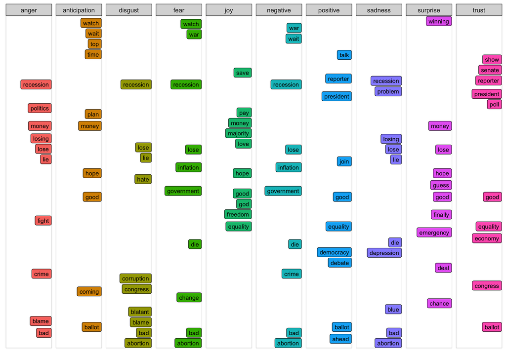

```r
y=1

nrc_sent %>%
  ggplot(aes(term, y, label = term, fill = sentiment)) +
  geom_point(color = "transparent") +
  geom_label_repel(force = 1, nudge_y = .5,
                   direction = "y",
                   box.padding = 0.05,
                   segment.color = "transparent",
                   size = 3) +
  facet_grid(~sentiment) +
  theme_bw()+
  theme(axis.text.x = element_blank(), axis.text.y = element_blank(),
        axis.title.x = element_text(size = 6),
        panel.grid = element_blank(), panel.background = element_blank(),
        panel.border = element_rect('lightgray', fill = NA),
        strip.text.x = element_text(size = 9),
        legend.position="none",
        axis.ticks.x = element_blank(),
        axis.ticks.y = element_blank()) +
  xlab(NULL) + ylab(NULL)+
  coord_flip()
```

#### Frequency of Top 10 Words

As we observed all of the words that can be found in each sentiment and emotion. With this facet wrap graph we can now see the frequency of each word per their emotion/sentiment. As stated previously some words fall into a category more than once.

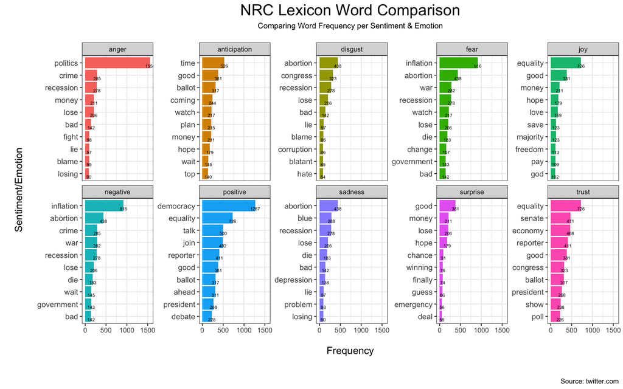

```r
nrc_sent %>%
  ggplot(aes( reorder(term, count), count, fill = sentiment)) +
  geom_col(show.legend = FALSE) +
  geom_text(aes(label=paste0('\n',count)), size=2) +
  theme_bw()+
  facet_wrap(~sentiment, scales = 'free_y', ncol =5)+
  coord_flip()+
    labs(title = "NRC Lexicon Word Comparison",
          subtitle = "Comparing Word Frequency per Sentiment & Emotion\n",
          x="\nSentiment/Emotion\n",
          y="\nFrequency\n",
          caption="\nSource: twitter.com")+
     theme(
       plot.title=element_text(hjust=.5,size = 20),
       plot.subtitle=element_text(hjust=.5,size = 10),
       axis.text.y=element_text(size=10),
       axis.title.x=element_text(size=13),
       axis.title.y=element_text(size=13))
```

### **Conclusion**

Based on the sentiment analysis conducted on data collected from users of the social media application Twitter, users of the app feel very negatively toward upcoming midterm elections. The frequency of the negative sentiment was dominant in both Bing and NRC lexicons. Two of the words that stood out the most in the Bing lexicon were crime and recession, both having a negative sentiment. The word politics in the NRC lexicon was found 1,556 times and has an association with the emotion anger. Other emotions that stood out were fear and anticipation. Fear was a top emotion found while anticipation ranked eight. With the use of both Bing and NRC lexicons we can conclude that Twitter users do feel negativity towards midterm elections and the political landscape. While this analysis was performed from a small collection of tweets, one wonders if the sentiment behind these tweets transfers to other users.